# Анализ программы лояльности магазина

## Введение

Нам предстоит изучить данные о покупках в магазине строительных материалов «Строили, строили и наконец построили». В магазинах сети действует программа лояльности. Все покупатели могут получить доступ в магазин с использованием персональных карт. За 200 рублей в месяц они могут стать участниками программы лояльности. В программу включены скидки, специальные предложения, подарки.

В нашем распоряжении два датасета. Файл retail_dataset.csv - выгрузка с информацией о покупках за период использования программы лояльности. Файл product_codes.csv - хранит информацию о стоимости единицы товаров.

**Цель исследования** — анализ эффективности программы лояльности. Поиск точек развития программы. Проверка статистических гипотез.

**Ход исследования**

Проверим данные на ошибки и оценим их влияние на исследование. Затем на этапе предобработки поищем возможность исправить самые критичные ошибки данных. Далее необходимо провести исследовательский анализ данных и перейти непосредственно к главным целям исследования.

Таким образом, исследование пройдет в несколько этапов:

1. Обзор данных и предобработка данных
2. Исследовательский анализ данных
3. Анализ эффективности программы лояльности, нахождение точек роста
4. Проверка статистических гипотез.

## Обзор и предобработка данных.

### Обзор данных.

```python
import pandas as pd  # Импортируем необходимые библиотеки, прочитаем файлы и сохраним их в переменные

import matplotlib.pyplot as plt
plt.style.use('seaborn-whitegrid')
import plotly.express as px
from plotly import graph_objects as go
import seaborn as sns

import scipy.stats as st
import numpy as np
import datetime as dt

import warnings as wr
wr.filterwarnings('ignore')
```

```python
purchases = pd.read_csv('retail_dataset.csv')
products = pd.read_csv('product_codes.csv')
```

```python
purchases.head() # Выведем первые 5 строк на экран
```

|  | purchaseid | item_ID | Quantity | purchasedate | CustomerID | ShopID | loyalty_program |
| --- | --- | --- | --- | --- | --- | --- | --- |
| 0 | 538280 | 21873 | 11 | 2016-12-10 12:50:00 | 18427.0 | Shop 0 | 0.0 |
| 1 | 538862 | 22195 | 0 | 2016-12-14 14:11:00 | 22389.0 | Shop 0 | 1.0 |
| 2 | 538855 | 21239 | 7 | 2016-12-14 13:50:00 | 22182.0 | Shop 0 | 1.0 |
| 3 | 543543 | 22271 | 0 | 2017-02-09 15:33:00 | 23522.0 | Shop 0 | 1.0 |
| 4 | 543812 | 79321 | 0 | 2017-02-13 14:40:00 | 23151.0 | Shop 0 | 1.0 |

```python
products.head()
```

|  | productID | price_per_one |
| --- | --- | --- |
| 0 | 85123A | 2.55 |
| 1 | 71053 | 3.39 |
| 2 | 84406B | 2.75 |
| 3 | 84029G | 3.39 |
| 4 | 84029E | 3.39 |

```python
purchases.info() # Получим общую информацию о таблицах
```

```
<class 'pandas.core.frame.DataFrame'>
RangeIndex: 105335 entries, 0 to 105334
Data columns (total 7 columns):
 #   Column           Non-Null Count   Dtype
---  ------           --------------   -----
 0   purchaseid       105335 non-null  object
 1   item_ID          105335 non-null  object
 2   Quantity         105335 non-null  int64
 3   purchasedate     105335 non-null  object
 4   CustomerID       69125 non-null   float64
 5   ShopID           105335 non-null  object
 6   loyalty_program  105335 non-null  float64
dtypes: float64(2), int64(1), object(4)
memory usage: 5.6+ MB
```

```python
products.info()
```

```
<class 'pandas.core.frame.DataFrame'>
RangeIndex: 9969 entries, 0 to 9968
Data columns (total 2 columns):
 #   Column         Non-Null Count  Dtype
---  ------         --------------  -----
 0   productID      9969 non-null   object
 1   price_per_one  9969 non-null   float64
dtypes: float64(1), object(1)
memory usage: 155.9+ KB
```

Согласно документации:

Файл retail_dataset.csv:

- `purchaseId` — id чека;
- `item_ID` — id товара;
- `purchasedate` — дата покупки;
- `Quantity` — количество товара;
- `CustomerID` — id покупателя;
- `ShopID` — id магазина;
- `loyalty_program` — участвует ли покупатель в программе лояльности;

Файл product_codes.csv:

- `productID` — id товара;
- `price_per_one` — стоимость одной единицы товара;

### Вывод по обзору данных.

**В таблице с данными о покупках** 105335 строк и 7 столбцов.

Наблюдаются пропуски значений в столбце CustomerID.

В называниях столбцов видны нарушения стиля, а именно строчные буквы сочетаются с прописными, некоторые названия необходимо записать в "змеином" регистре.

Данные столбца purchasedate небходимо перевести из строк в даты, поменяв тип данных. Тип данных столбца loyalty_program изменим на тип int64.

**В таблице с данными о ценах на единицу товара** 9969 строк и 2 столбца.

Название столбца productID необходимо привести в соответствие с хорошим стилем.

Данные столбца loyalty_program яляются категориальными, для удобства переименуем 0 и 1 в "не участвует" и в "лояльный" соответственно.

### Предобработка данных.

#### Переименование столбцов.

Приведем названия столбцов к нижнему регистру и добавим нижнее подчеркивание.

```python
purchases.columns = purchases.columns.str.lower()
```

```python
purchases = purchases.rename(columns = {
    'purchaseid':'purchase_id',
    'purchasedate':'purchase_date',
    'customerid':'customer_id',
    'shopid':'shop_id'

}
                     )
```

```python
products = products.rename(columns = {'productID':'product_id'})
```

Проверим названия столбцов.

```python
purchases.columns
```

```
Index(['purchase_id', 'item_id', 'quantity', 'purchase_date', 'customer_id',
       'shop_id', 'loyalty_program'],
      dtype='object')
```

```python
products.columns
```

```
Index(['product_id', 'price_per_one'], dtype='object')
```

Переименуем категории клиентов по лояльности.

```python
def categorize(loyalty):
    try:
        if loyalty == 1:
            return 'лояльный'
        elif loyalty == 0:
            return 'не участвует'
    except:
        pass
```

```python
purchases['loyalty_program'] = purchases['loyalty_program'].apply(categorize)
```

#### Работа с пропусками.

Мы выявили пропуски значений в столбце customer_id таблицы purchases. Природа этих пропусков возможно связана с тем, что не всегда покупатель регистрировался, покупал разово, оплатив наличными.

```python
purchases.isna().agg(['mean', 'sum']).T.sort_values(by='mean', ascending=False) # посмотрим доли пропусков
```

|  | mean | sum |
| --- | --- | --- |
| customer_id | 0.34376 | 36210.0 |
| purchase_id | 0.00000 | 0.0 |
| item_id | 0.00000 | 0.0 |
| quantity | 0.00000 | 0.0 |
| purchase_date | 0.00000 | 0.0 |
| shop_id | 0.00000 | 0.0 |
| loyalty_program | 0.00000 | 0.0 |

На долю пропусков приходится около 35 % id покупателей. Посмотрим на распределение пропусков в разрезе лояльных/нелояльных покупателей.

```python
purchases[purchases['loyalty_program'] == 1.0]['customer_id'].isna().agg(['mean', 'sum'])
```

```
mean    NaN
sum     0.0
Name: customer_id, dtype: float64
```

```python
purchases[purchases['loyalty_program'] == 0.0]['customer_id'].isna().agg(['mean', 'sum'])
```

```
mean    NaN
sum     0.0
Name: customer_id, dtype: float64
```

```python
purchases['customer_id'] = purchases['customer_id'].fillna(purchases['purchase_id'])
```

#### Изменение типов данных.

Данные столбца purchase_date переведем из строк в даты.

```python
purchases['purchase_date'] = pd.to_datetime(purchases['purchase_date'])
```

Тип данных столбца loyalty_program изменим на тип int64.

#### Проверка на явные дубликаты.

```python
purchases.duplicated().sum()
```

```
1033
```

```python
products.duplicated().sum()
```

```
0
```

Мы обнаружили 1033 явных дубликата в таблице purchases, посмотрим есть ли определенная закономерность появления дубликатов в данных.

```python
duplicated_purchases = purchases[purchases.duplicated()] # создадим таблицу с дубликатами
duplicated_purchases.value_counts('shop_id')
```

```
shop_id
Shop 0     1023
Shop 25       4
Shop 4        2
Shop 6        2
Shop 18       1
Shop 2        1
dtype: int64
```

При проверке соотношений дубликатов по столбцам было обнаружено, что 1023 дубликата из 1033 принадлежит магазину Shop 0

```python
duplicated_purchases.value_counts('quantity') # посмотрим количество значений по столбцу quantity.
```

```
quantity
 0      693
 1      121
 5       48
 11      46
-2       38
 2       16
 3       14
 7       13
 4       12
 23      11
 9        8
 24       4
-13       2
-3        2
 31       1
 47       1
 6        1
 15       1
 143      1
dtype: int64
```

Среди дубликатов (693 строки), соответственно и в магазине Shop 0 обнаружено множество строк чеков с нулевым значением товара.

**Мы решили удалить дубликаты. После удаления останется 104302 строки.** В связи с открывшимися наблюдениями по Shop 0, нам необходимо изучить этот магазин подробнее в дальнейших исследованиях.

```python
purchases = purchases.drop_duplicates().reset_index(drop=True)
```

```python
purchases.duplicated().sum()
```

```
0
```

```python
purchases.info()
```

```
<class 'pandas.core.frame.DataFrame'>
RangeIndex: 104302 entries, 0 to 104301
Data columns (total 7 columns):
 #   Column           Non-Null Count   Dtype
---  ------           --------------   -----
 0   purchase_id      104302 non-null  object
 1   item_id          104302 non-null  object
 2   quantity         104302 non-null  int64
 3   purchase_date    104302 non-null  datetime64[ns]
 4   customer_id      104302 non-null  object
 5   shop_id          104302 non-null  object
 6   loyalty_program  104302 non-null  object
dtypes: datetime64[ns](1), int64(1), object(5)
memory usage: 5.6+ MB
```

#### Проверка на неявные дубликаты.

Проверим столбцы 'shop_id', 'loyalty_program' датафрейма purchases на неявные дубликаты. Выведем список уникальных значений этих столбцов.

```python
purchases['shop_id'].unique()
```

```
array(['Shop 0', 'Shop 1', 'Shop 4', 'Shop 6', 'Shop 2', 'Shop 11',
       'Shop 3', 'Shop 5', 'Shop 7', 'Shop 12', 'Shop 8', 'Shop 27',
       'Shop 10', 'Shop 20', 'Shop 19', 'Shop 25', 'Shop 14', 'Shop 21',
       'Shop 18', 'Shop 9', 'Shop 16', 'Shop 28', 'Shop 29', 'Shop 17',
       'Shop 22', 'Shop 13', 'Shop 26', 'Shop 24', 'Shop 15', 'Shop 23',
       'Shop 30'], dtype=object)
```

Неявных дубликатов в заданых столбцах не обнаружено. В датафрейме представлен 31 магазин.

#### Статистические показатели численных данных.

```python
purchases.describe()
```

|  | quantity |
| --- | --- |
| count | 104302.000000 |
| mean | 7.883003 |
| std | 329.565540 |
| min | -74216.000000 |
| 25% | 0.000000 |
| 50% | 2.000000 |
| 75% | 7.000000 |
| max | 74214.000000 |

**В столбце quantity присутствуют отрицательные значения.** Возможно это возврат товара. Этот момент небходимо будет изучить в дальнейшем исследовании. Это значительно влияет на средние и медианные показатели этого столбца.

```python
products.describe()
```

|  | price_per_one |
| --- | --- |
| count | 9969.000000 |
| mean | 19.503697 |
| std | 330.880754 |
| min | 0.000000 |
| 25% | 1.250000 |
| 50% | 2.550000 |
| 75% | 5.510000 |
| max | 16888.020000 |

Среденее (19,5) и медиана (2,6) цен на товары рознятся, что говорит о выбросах. Учтем этот момент при агрегировании цен.

#### Объединение таблиц.

Для того, чтобы проводить дальнейшее исследование, необходимо провести объединение датафреймов с покупками и с ценами на товары. Судя по данным , есть возможность объединения по id товара: столбец item_id в purchases и столбец product_id в products. Так как в purchases представлены строки чеков, то мы не можем говорить об уникальности наименований в столбце. Проверим уникальные id товаров таблицы products.

```python
purchases['item_id'].nunique() # уникальные значения
```

```
3159
```

```python
products['product_id'].count() # количество строк
```

```
9969
```

Количество уникальных id продуктов почти в 3 раза меньше общего количества строк датафрейма products. Это означает, что одному id товара соответствует несколько цен. Это существенно осложнит работу над объединением таблиц, поэтому Id продуктов необходимо сгруппировать и сагрегировать цены. Выведем количество цен в разбивке по значениям id.

```python
products['product_id'].value_counts().head(10)
```

```
DOT       174
M          59
S          29
POST       15
D          13
79321      11
84406B     10
47566      10
21670       9
22112       9
Name: product_id, dtype: int64
```

В id товаров присутствуют буквенные и числовые обозначения. Причем топ возглавляют именно буквенные аббревиатуры. Изучим эти аббревиатуры подробнее.

```python
products.groupby('product_id').count().tail(25)
```

| product_id | price_per_one |
| --- | --- |
| 90214Y | 1 |
| 90214Z | 1 |
| AMAZONFEE | 9 |
| BANK CHARGES | 8 |
| C2 | 3 |
| D | 13 |
| DCGS0003 | 2 |
| DCGS0055 | 1 |
| DCGS0057 | 1 |
| DCGS0069 | 1 |
| DCGS0070 | 1 |
| DCGS0072 | 1 |
| DCGS0074 | 1 |
| DCGS0076 | 1 |
| DCGSSBOY | 1 |
| DCGSSGIRL | 1 |
| DOT | 174 |
| M | 59 |
| POST | 15 |
| S | 29 |
| gift_0001_20 | 2 |
| gift_0001_30 | 2 |
| gift_0001_40 | 1 |
| gift_0001_50 | 1 |
| m | 1 |

```python
another_items = purchases[purchases['item_id'].isin(['AMAZONFEE','BANK CHARGES','C2','D','DCGS0003','DCGS0055',
'DCGS0057','DCGS0069','DCGS0070','DCGS0072','DCGS0074','DCGS0076','DCGSSBOY','DCGSSGIRL','DOT','M','POST','S','gift_0001_20',
'gift_0001_30','gift_0001_40','gift_0001_50','m'])]
```

```python
another_items.value_counts('shop_id')
```

```
shop_id
Shop 0     330
Shop 4      73
Shop 1      63
Shop 6      16
Shop 12     16
Shop 10     12
Shop 8      11
Shop 11      7
Shop 3       6
Shop 7       6
Shop 22      4
Shop 18      3
Shop 20      3
Shop 19      3
Shop 17      2
Shop 16      1
Shop 5       1
dtype: int64
```

В большей степени количество буквенных обозначений товаров приходится на Shop_0. Это необходимо зафиксировать для дальнейшего изучения данного магазина.

```python
another_items.value_counts('quantity').head()
```

```
quantity
 0    306
-2     77
 1     51
 2     36
 5     18
dtype: int64
```

Большинство подобных товаров отпускалось количеством 0 , что позволяет задуматься о том, что буквенными id могут обозначаться не штучные товары как таковые, а какого-либо рода услуги. Аббревиатуру POST можно расшифровать как "Точка продаж терминал"(с англ. Point Of Sales Terminal). DOT - В оговоренные сроки (с англ. Delivered on Time) или дотком почта. AMAZONFEE платежи, связанные с сайтом Амазон. Наименования с подстрокой gift может означать подарок, либо сертификат. **Мы решили удалить строки, с Id с буквенными значениями, так как это не физические товары.**

```python
not_items = list(another_items['item_id'])
```

```python
products = products.query('product_id != @not_items')
```

```python
purchases = purchases.query('item_id != @not_items')
```

Мы приняли решение сгруппировать данные таблицы products по product_id и сагрегировать данные по медиане, так как она более устойчива к выбросам.

```python
products = products.groupby('product_id').agg({'price_per_one':'median'}).reset_index()
products
```

|  | product_id | price_per_one |
| --- | --- | --- |
| 0 | 10002 | 1.63 |
| 1 | 10080 | 0.85 |
| 2 | 10120 | 0.21 |
| 3 | 10123C | 0.65 |
| 4 | 10124A | 0.42 |
| ... | ... | ... |
| 3131 | 90214T | 0.84 |
| 3132 | 90214V | 0.85 |
| 3133 | 90214W | 0.84 |
| 3134 | 90214Y | 0.85 |
| 3135 | 90214Z | 0.85 |

3136 rows × 2 columns

Теперь посчитаем количество уникальных id товаров в purchases.

```python
purchases['item_id'].nunique()
```

```
3136
```

Количество уникальных id товаров в таблицах совпадает, поэтому мы можем приступить к объединению таблиц.

```python
products = products.rename(columns = {'product_id':'item_id'})
```

```python
products.head()
```

|  | item_id | price_per_one |
| --- | --- | --- |
| 0 | 10002 | 1.63 |
| 1 | 10080 | 0.85 |
| 2 | 10120 | 0.21 |
| 3 | 10123C | 0.65 |
| 4 | 10124A | 0.42 |

```python
data = purchases.merge(products, on='item_id', how = 'left')
```

```python
data.shape
```

```
(103745, 8)
```

#### Вывод по предобработке данных.

В ходе предобработки данных мы переименовали столбцы в соответствие с "хорошим" стилем.

Проработали ситуацию с пропусками в столбце customer_id. Восстановить пропуски соответствющими названиями чеков.

Проверка на явные дубликаты показала их наличие в количестве 1033 строк. Мы решили их удалить, так как их количество невелико и их удаление не повлияет на качество исследования.

Для того, чтобы провести дальнейшее исследование, необходимо было объединить датафреймы с покупками и с ценами на товары. Мы решили сагрегировать цены на товары в таблице products по медианной цене, так как наблюдаются выбросы в целом по столбцу product_id и скорее всего подобная ситуация происходит и внутри групп по наименованию товара. Предварительно мы выявили некоторое количество непродуктовых кодов, начинающихся с буквы. Расшифровать в полной мере подобные коды не представляется возможным, мы можем только догадываться, что означет тот или иной подобный код. Так как дополнительной информации клиент не предоставит по расшифровке этих кодов, мы решили удалить строки с подобными кодами, так как мы будем изучать выручку и количество товаров, непосредственно желаемых клиентом.

В итоге **мы получили 103745 строк и 8 столбцов в новом объединенном датафрейме**.

## Исследовательский анализ данных.

### Нулевые и отрицательные значения.

Для начала мы исследуем те особенности датафрейма, которые были выявлены на этапе предобработки, а именно то, что в нем представлены нулевые и отрицательные значения в столбце quantity(количество товара). Посмотрим сколько их.

```python
data.query('quantity <= 0')
```

|  | purchase_id | item_id | quantity | purchase_date | customer_id | shop_id | loyalty_program | price_per_one |
| --- | --- | --- | --- | --- | --- | --- | --- | --- |
| 1 | 538862 | 22195 | 0 | 2016-12-14 14:11:00 | 22389.0 | Shop 0 | лояльный | 3.290 |
| 3 | 543543 | 22271 | 0 | 2017-02-09 15:33:00 | 23522.0 | Shop 0 | лояльный | 4.370 |
| 4 | 543812 | 79321 | 0 | 2017-02-13 14:40:00 | 23151.0 | Shop 0 | лояльный | 5.750 |
| 5 | 538379 | 22965 | 0 | 2016-12-12 11:26:00 | 22805.0 | Shop 0 | лояльный | 3.115 |
| 6 | 540468 | 22189 | 0 | 2017-01-07 13:55:00 | 540468 | Shop 0 | не участвует | 3.950 |
| ... | ... | ... | ... | ... | ... | ... | ... | ... |
| 103724 | 538073 | 22439 | 0 | 2016-12-09 14:10:00 | 23495.0 | Shop 0 | лояльный | 1.250 |
| 103725 | 543306 | 22898 | 0 | 2017-02-07 11:56:00 | 22365.0 | Shop 0 | лояльный | 4.130 |
| 103726 | 543013 | 22266 | 0 | 2017-02-02 13:35:00 | 543013 | Shop 0 | не участвует | 0.950 |
| 103737 | 538349 | 22625 | 0 | 2016-12-10 14:59:00 | 538349 | Shop 0 | не участвует | 8.500 |
| 103741 | 540247 | 21742 | 0 | 2017-01-05 15:56:00 | 21143.0 | Shop 0 | не участвует | 9.335 |

34046 rows × 8 columns

Около трети строк составляют нулевые и отрицательные значения количества товаров.

```python
data.query('quantity <= 0').value_counts('shop_id')
```

```
shop_id
Shop 0     33529
Shop 4       176
Shop 1        86
Shop 6        70
Shop 8        53
Shop 14       41
Shop 18       38
Shop 12       12
Shop 10       11
Shop 11        8
Shop 3         7
Shop 2         5
Shop 16        3
Shop 21        2
Shop 7         2
Shop 19        1
Shop 20        1
Shop 23        1
dtype: int64
```

Львиная доля "странных" значений приходится на Shop_0.

Проверим наименования чеков.

```python
data.query('quantity <= 0')['purchase_id'].unique()
```

```
array(['538862', '543543', '543812', ..., 'C537157', '540564', '542572'],
      dtype=object)
```

Выявлено, что кроме числовых обозначений, чеки могут содержать буквы. Выделим чеки с буквами и посмотрим чем они отличаются от численных.

```python
data[data['purchase_id'].str.isdigit() != True]
```

|  | purchase_id | item_id | quantity | purchase_date | customer_id | shop_id | loyalty_program | price_per_one |
| --- | --- | --- | --- | --- | --- | --- | --- | --- |
| 64 | C539944 | 22776 | -2 | 2016-12-23 11:38:00 | 20239.0 | Shop 0 | не участвует | 14.955 |
| 109 | C542910 | 20726 | -2 | 2017-02-01 15:38:00 | 23190.0 | Shop 0 | лояльный | 4.130 |
| 112 | C542426 | 22418 | -25 | 2017-01-28 09:32:00 | 19825.0 | Shop 0 | не участвует | 1.645 |
| 252 | C539726 | 22791 | -11 | 2016-12-21 14:24:00 | 22686.0 | Shop 0 | лояльный | 1.855 |
| 343 | C544034 | 21878 | -2 | 2017-02-15 11:28:00 | 20380.0 | Shop 0 | не участвует | 1.240 |
| ... | ... | ... | ... | ... | ... | ... | ... | ... |
| 103472 | C544397 | 22063 | -2 | 2017-02-18 12:21:00 | 18141.0 | Shop 8 | не участвует | 5.790 |
| 103586 | C540246 | 79320 | -2 | 2017-01-05 15:43:00 | 18760.0 | Shop 0 | не участвует | 4.950 |
| 103623 | C539467 | 22801 | -2 | 2016-12-19 12:46:00 | 20723.0 | Shop 0 | не участвует | 5.605 |
| 103660 | C540847 | 22197 | -3 | 2017-01-11 17:35:00 | 19137.0 | Shop 0 | не участвует | 1.240 |
| 103710 | C540164 | 21144 | -13 | 2017-01-05 12:02:00 | 20590.0 | Shop 6 | не участвует | 1.870 |

1780 rows × 8 columns

Проверим все ли подобные чеки начинаются с 'C'.

```python
data[data['purchase_id'].str.isdigit() != True]['purchase_id'].str.startswith('C').value_counts()
```

```
True    1780
Name: purchase_id, dtype: int64
```

Все чеки с буквенными обозначениями в коде начинаются на 'C', проверим сколько подобных кодов в разрезе отрицательных значений.

```python
data.query('quantity < 0')[data.query('quantity < 0')['purchase_id'].str.isdigit() != True]
```

|  | purchase_id | item_id | quantity | purchase_date | customer_id | shop_id | loyalty_program | price_per_one |
| --- | --- | --- | --- | --- | --- | --- | --- | --- |
| 64 | C539944 | 22776 | -2 | 2016-12-23 11:38:00 | 20239.0 | Shop 0 | не участвует | 14.955 |
| 109 | C542910 | 20726 | -2 | 2017-02-01 15:38:00 | 23190.0 | Shop 0 | лояльный | 4.130 |
| 112 | C542426 | 22418 | -25 | 2017-01-28 09:32:00 | 19825.0 | Shop 0 | не участвует | 1.645 |
| 252 | C539726 | 22791 | -11 | 2016-12-21 14:24:00 | 22686.0 | Shop 0 | лояльный | 1.855 |
| 343 | C544034 | 21878 | -2 | 2017-02-15 11:28:00 | 20380.0 | Shop 0 | не участвует | 1.240 |
| ... | ... | ... | ... | ... | ... | ... | ... | ... |
| 103472 | C544397 | 22063 | -2 | 2017-02-18 12:21:00 | 18141.0 | Shop 8 | не участвует | 5.790 |
| 103586 | C540246 | 79320 | -2 | 2017-01-05 15:43:00 | 18760.0 | Shop 0 | не участвует | 4.950 |
| 103623 | C539467 | 22801 | -2 | 2016-12-19 12:46:00 | 20723.0 | Shop 0 | не участвует | 5.605 |
| 103660 | C540847 | 22197 | -3 | 2017-01-11 17:35:00 | 19137.0 | Shop 0 | не участвует | 1.240 |
| 103710 | C540164 | 21144 | -13 | 2017-01-05 12:02:00 | 20590.0 | Shop 6 | не участвует | 1.870 |

1780 rows × 8 columns

Это означает, что буква 'C' в названии чека присваивается некоторым отрицательным значениям количества товаров. Возможно так обозначется какой либо вид списания или отмены товара.

Что касается нулей в значениях количества товаров. Прослеживается связь с магазином shop_0. Предварительно, можно рассуждать так: так как на данный магазин приходится очень большое количество строк чеков, услуг, связанных с продажами в интернете, большое количество отрицательных и нулевых значений количества товаров, можно предположить, что Shop_0 это сборка чеков с продаж онлайн через интернет. Возможно через известные маркетплейсы. Это может объяснить и большое количество чеков, отрицательных и нулевых значений количества товаров, так как зачастую онлайн клиент покупает "вслепую", может отказаться от товара предумав, или увидев брак.

В связи с этим мы решили удалить все нулевые и отрицательные значения, так как мы будем изучать выручку с продажи товара, количество проданного товара на тот момент, когда клиент принял решение его приобрести.

Удалим все нулевые и отрицательные значения количества товара из итоговой таблицы data.

```python
data = data.query('quantity > 0').reset_index(drop=True)
```

```python
data.shape
```

```
(69699, 8)
```

### Базовые проверки.

В датафрейме присутствует большое количество неидентифицированных клиентов. Посмотрим сколько индентифицируемых клиентов.

```python
determined_customers = data[data['customer_id'] != data['purchase_id']] # выделим идентифицируемых покупателей
print('Количество уникальных покупателей с индентификаторами в датафрейме:', determined_customers['customer_id'].nunique())
```

```
Количество уникальных покупателей с индентификаторами в датафрейме: 1671
```

Посмотрим сколько среди них лояльных клиентов.

```python
print('Количество уникальных лояльных покупателей в датафрейме:', determined_customers[determined_customers['loyalty_program'] == 1]['customer_id'].nunique())
```

```
Количество уникальных лояльных покупателей в датафрейме: 0
```

```python
data['purchase_date'].min()
```

```
Timestamp('2016-12-01 08:26:00')
```

```python
data['purchase_date'].max()
```

```
Timestamp('2017-02-28 17:01:00')
```

```python
data['purchase_date'].max()-data['purchase_date'].min()
```

```
Timedelta('89 days 08:35:00')
```

Нам предоставлены данные за 3 месяца - с декабря 2016 по февраль 2017. Посмотрим сколько заказов было произведено за этот период.

```python
print('Количество заказов в датафрейме:', data['purchase_id'].nunique())
```

```
Количество заказов в датафрейме: 3707
```

Для дальнейшего исследования добавим столбец с выделенной датой, неделей и днем недели для каждой покупки. А также столбец с выручкой по строкам чеков.

```python
data['date'] = data['purchase_date'].dt.date
```

```python
data['week'] = data['purchase_date'].dt.week
```

```python
data['weekday'] = data['purchase_date'].dt.weekday
```

```python
data['month'] = data['purchase_date'].dt.month
```

```python
data['weekday'].unique()
```

```
array([5, 2, 1, 3, 4, 0], dtype=int64)
```

Шестой день недели отсутствует, можно сделать вывод, что воскресенье выходной день.

```python
data['revenue'] = data['quantity'] * data['price_per_one']
```

```python
data
```

|  | purchase_id | item_id | quantity | purchase_date | customer_id | shop_id | loyalty_program | price_per_one | date | week | weekday | month | revenue |
| --- | --- | --- | --- | --- | --- | --- | --- | --- | --- | --- | --- | --- | --- |
| 0 | 538280 | 21873 | 11 | 2016-12-10 12:50:00 | 18427.0 | Shop 0 | не участвует | 1.630 | 2016-12-10 | 49 | 5 | 12 | 17.930 |
| 1 | 538855 | 21239 | 7 | 2016-12-14 13:50:00 | 22182.0 | Shop 0 | лояльный | 1.630 | 2016-12-14 | 50 | 2 | 12 | 11.410 |
| 2 | 541424 | 79321 | 1 | 2017-01-17 17:57:00 | 541424 | Shop 0 | не участвует | 5.750 | 2017-01-17 | 3 | 1 | 1 | 5.750 |
| 3 | 537795 | 82494L | 5 | 2016-12-08 13:03:00 | 22892.0 | Shop 0 | лояльный | 5.205 | 2016-12-08 | 49 | 3 | 12 | 26.025 |
| 4 | 541696 | 22197 | 4 | 2017-01-20 18:08:00 | 541696 | Shop 0 | не участвует | 1.240 | 2017-01-20 | 3 | 4 | 1 | 4.960 |
| ... | ... | ... | ... | ... | ... | ... | ... | ... | ... | ... | ... | ... | ... |
| 69694 | 540154 | 22134 | 3 | 2017-01-05 11:30:00 | 540154 | Shop 0 | не участвует | 0.630 | 2017-01-05 | 1 | 3 | 1 | 1.890 |
| 69695 | 538566 | 21826 | 1 | 2016-12-13 11:21:00 | 538566 | Shop 0 | не участвует | 2.460 | 2016-12-13 | 50 | 1 | 12 | 2.460 |
| 69696 | 538068 | 85048 | 1 | 2016-12-09 14:05:00 | 23657.0 | Shop 0 | лояльный | 8.330 | 2016-12-09 | 49 | 4 | 12 | 8.330 |
| 69697 | 538207 | 22818 | 11 | 2016-12-10 11:33:00 | 18427.0 | Shop 0 | не участвует | 0.830 | 2016-12-10 | 49 | 5 | 12 | 9.130 |
| 69698 | 543977 | 22384 | 9 | 2017-02-14 15:35:00 | 21294.0 | Shop 0 | не участвует | 4.130 | 2017-02-14 | 7 | 1 | 2 | 37.170 |

69699 rows × 13 columns

```python
print('Общая выручка:', round(data['revenue'].sum(), 2))
```

```
Общая выручка: 2377986.02
```

### Исследование магазинов.

На этапе предобработки нас заинтересовал магазин Shop_0, в связи с этим мы решили исследовать магазины на предмет особенностей.

```python
print('В датафрейме представлено магазинов в количестве:', data['shop_id'].nunique())
```

```
В датафрейме представлено магазинов в количестве: 31
```

Посмотрим как распределены покупки и выручка по магазинам.

```python
shop_purchases = data.groupby('shop_id').agg({'purchase_id':'nunique', 'revenue':'sum'}).reset_index()
shop_purchases.columns = ['shop_id', 'purchase_cnt', 'revenue']
shop_purchases = shop_purchases.sort_values(by='revenue', ascending=False).reset_index(drop=True)
shop_purchases
```

|  | shop_id | purchase_cnt | revenue |
| --- | --- | --- | --- |
| 0 | Shop 0 | 3382 | 1947733.535 |
| 1 | Shop 3 | 13 | 101940.150 |
| 2 | Shop 6 | 37 | 62409.140 |
| 3 | Shop 4 | 78 | 51553.555 |
| 4 | Shop 1 | 69 | 46978.590 |
| 5 | Shop 2 | 17 | 39523.415 |
| 6 | Shop 14 | 4 | 22346.055 |
| 7 | Shop 8 | 16 | 16876.485 |
| 8 | Shop 19 | 5 | 11247.870 |
| 9 | Shop 7 | 10 | 11167.180 |
| 10 | Shop 10 | 12 | 9673.020 |
| 11 | Shop 12 | 16 | 6659.330 |
| 12 | Shop 18 | 6 | 6656.665 |
| 13 | Shop 5 | 4 | 6202.610 |
| 14 | Shop 11 | 6 | 3990.320 |
| 15 | Shop 24 | 1 | 3984.625 |
| 16 | Shop 16 | 3 | 3896.055 |
| 17 | Shop 25 | 1 | 3234.265 |
| 18 | Shop 22 | 4 | 2925.530 |
| 19 | Shop 26 | 1 | 2775.590 |
| 20 | Shop 9 | 4 | 2415.115 |
| 21 | Shop 13 | 4 | 2410.330 |
| 22 | Shop 17 | 2 | 2132.530 |
| 23 | Shop 27 | 1 | 2095.470 |
| 24 | Shop 15 | 2 | 1736.520 |
| 25 | Shop 21 | 2 | 1629.600 |
| 26 | Shop 28 | 1 | 1621.895 |
| 27 | Shop 20 | 3 | 994.080 |
| 28 | Shop 30 | 1 | 743.530 |
| 29 | Shop 23 | 1 | 225.250 |
| 30 | Shop 29 | 1 | 207.715 |

Только 10 магазинов из 31 имеют от 10 и больше покупок. Особняком выделяется Shop_0 с огромным количеством покупок. Все эти магазины не похожи на торговые точки в плане физического магазина. Скорее всего здесь представлены данные о продажах с различных площадок. И все они в разной степени освоены сетью. Выборки количества покупок, выручки по всем магазинам кроме Shop_0 недостаточно качествены для анализа. Поэтому в дальнейшем исследование программы лояльности мы продолжим на основе выборки данных магазина Shop_0. Так как там действительно возможно проследить реализацию программы.

### Исследование выбросов и аномалий.

Исследуем гистограмму значений столбца с датами.

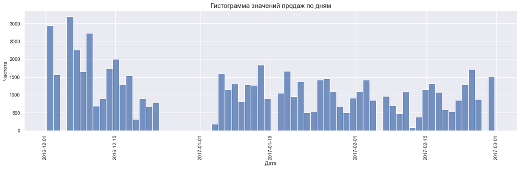

```python
fig, ax = plt.subplots(figsize=(20,5))
sns.histplot(data['purchase_date'], bins = data['date'].nunique())
ax.set_xlabel('Дата')
ax.set_ylabel('Частота')
ax.set_title('Гистограмма значений продаж по дням', fontsize=15)
plt.xticks(rotation=90)
plt.show()
```

Пик продаж приходится на первую половину декабря, большой перерыв в продажах наблюдается в конце декабря - начале января (период праздников), причем празники приходятся на католический рождественский период. Явно прослеживается сезонность товаров. Возможно больщие закупки осуществлялись в декабре сцелью успеть купить по старым ценам 2016 года, либо для юр. компаний цель освоить бюджет до конца года.

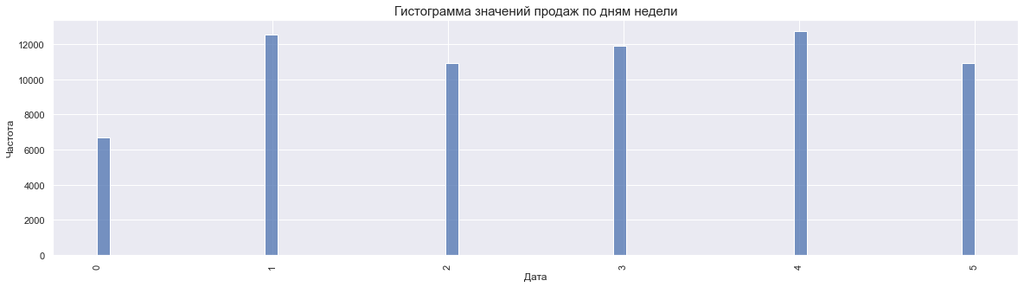

```python
fig, ax = plt.subplots(figsize=(20,5))
sns.histplot(data['weekday'], bins = data['date'].nunique())
ax.set_xlabel('Дата')
ax.set_ylabel('Частота')
ax.set_title('Гистограмма значений продаж по дням недели', fontsize=15)
plt.xticks(rotation=90)
plt.show()
```

Во вторник и пятницу наблюдаются пиковые продажи. Меньше всего продаж в понедельник. Как мы уже выяснили, в воскресенье продажи не осуществлялись.

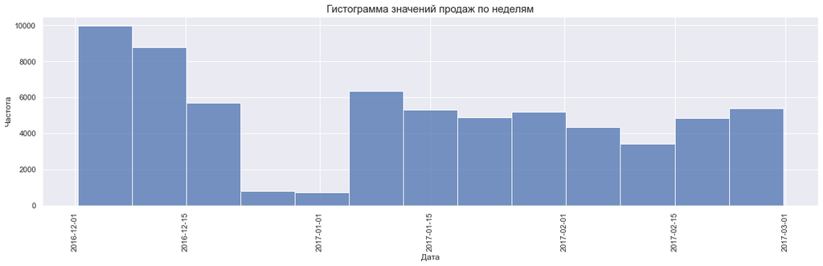

```python
fig, ax = plt.subplots(figsize=(20,5))
sns.histplot(data['purchase_date'], bins = data['week'].nunique())
ax.set_xlabel('Дата')
ax.set_ylabel('Частота')
ax.set_title('Гистограмма значений продаж по неделям', fontsize=15)
plt.xticks(rotation=90)
plt.show()
```

Ожидаемо низкое распределение количества продаж в праздничный новогодний период.

```python
data.describe()
```

|  | quantity | price_per_one | week | weekday | month | revenue |
| --- | --- | --- | --- | --- | --- | --- |
| count | 69699.00000 | 69699.000000 | 69699.000000 | 69699.000000 | 69699.000000 | 69699.000000 |
| mean | 13.48774 | 3.863534 | 21.732894 | 2.682908 | 5.492260 | 34.117936 |
| std | 286.19834 | 5.170895 | 21.853560 | 1.607390 | 5.146387 | 317.463287 |
| min | 1.00000 | 0.000000 | 1.000000 | 0.000000 | 1.000000 | 0.000000 |
| 25% | 2.00000 | 1.630000 | 4.000000 | 1.000000 | 1.000000 | 5.790000 |
| 50% | 5.00000 | 2.550000 | 7.000000 | 3.000000 | 2.000000 | 13.640000 |
| 75% | 11.00000 | 4.370000 | 49.000000 | 4.000000 | 12.000000 | 27.335000 |
| max | 74214.00000 | 265.500000 | 51.000000 | 5.000000 | 12.000000 | 77182.560000 |

Необходимо более детально изучить данные столбцов quantity и price_per_one. По ним наблюдаются нулевые значения и выбросы. Оценим количество товаров ещё одним способом:

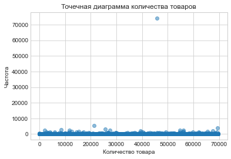

```python
x_values = pd.Series(range(0,len(data['quantity'])))
plt.scatter(x_values, data['quantity'], alpha = 0.5)
plt.title('Точечная диаграмма количества товаров')
plt.xlabel('Количество товара')
plt.ylabel('Частота')
plt.show()
```

Есть немного выбросов. Проведем подсчет перцентелей.

```python
print(np.percentile(data['quantity'], [90, 95, 99]))
```

```
[ 23.  39. 119.]
```

Не более 5% значений количества товаров превышает 39 шт и не более 1% превышает 119 шт. Мы выберем границу в 39 штук и отсеим аномальные значения по ней.

Исследуем значения столбца price_per_one.

```python
data['price_per_one'].value_counts().reset_index().sort_values(by = 'index').head()
```

|  | index | price_per_one |
| --- | --- | --- |
| 289 | 0.000 | 11 |
| 348 | 0.060 | 5 |
| 396 | 0.095 | 2 |
| 330 | 0.100 | 6 |
| 352 | 0.105 | 5 |

Нулевых значений цен немного, поэтому они не повлияют негативно на наше исследование. Посмотрим на распределение цен.

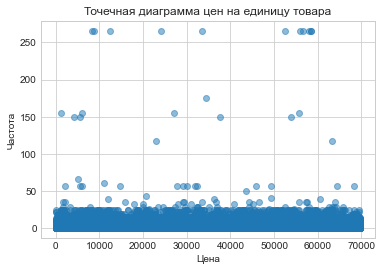

```python
x2_values = pd.Series(range(0,len(data['price_per_one'])))
plt.scatter(x2_values, data['price_per_one'],  alpha = 0.5)
plt.title('Точечная диаграмма цен на единицу товара')
plt.xlabel('Цена')
plt.ylabel('Частота')
plt.show()
```

Есть выбросы проведем расчет перцентелей.

```python
print(np.percentile(data['price_per_one'], [90, 95, 99]))
```

```
[ 7.87 11.04 15.37]
```

Не более 5% значений цен на единицу товаров превышает значение 11.04 и не более 1% превышает 15.37. Мы выберем границу в 15.37 и отсеим аномальные значения по ней.

```python
data = data.query('quantity <= 39 & price_per_one <= 15.37')
```

```python
data.info()
```

```
<class 'pandas.core.frame.DataFrame'>
Int64Index: 65716 entries, 0 to 69698
Data columns (total 13 columns):
 #   Column           Non-Null Count  Dtype
---  ------           --------------  -----
 0   purchase_id      65716 non-null  object
 1   item_id          65716 non-null  object
 2   quantity         65716 non-null  int64
 3   purchase_date    65716 non-null  datetime64[ns]
 4   customer_id      65716 non-null  object
 5   shop_id          65716 non-null  object
 6   loyalty_program  65716 non-null  object
 7   price_per_one    65716 non-null  float64
 8   date             65716 non-null  object
 9   week             65716 non-null  int64
 10  weekday          65716 non-null  int64
 11  month            65716 non-null  int64
 12  revenue          65716 non-null  float64
dtypes: datetime64[ns](1), float64(2), int64(4), object(6)
memory usage: 7.0+ MB
```

Из 69699 строк датафрейма у нас осталось 65716.

## Анализ эффективности программы лояльности, нахождение точек роста.

### Основные метрики в рамках программы лояльности.

Программу лояльности будем рассматривать на основе данных магазина Shop 0. Посмотрим соотношение количества клиентов по лояльности.

```python
customers1 = data.query('shop_id == "Shop 0"').groupby('loyalty_program')['customer_id'].nunique().reset_index()
customers1
```

|  | loyalty_program | customer_id |
| --- | --- | --- |
| 0 | лояльный | 539 |
| 1 | не участвует | 1248 |

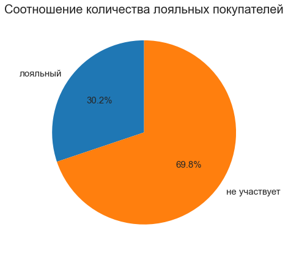

```python
fig1, ax1 = plt.subplots()
ax1.pie(customers1['customer_id'], labels=customers1['loyalty_program'], autopct='%1.1f%%', startangle = 90, textprops={'fontsize':15})
ax1.axis('equal')
ax1.set_title('Соотношение количества лояльных покупателей', fontsize=20)
fig1.set_figheight(7)
plt.show()
```

Количество лояльных клиентов около 30 % от общего количества.

Посмотрим долю выручки лояльных клиентов, по отношению к остальным.

```python
customers2 = data.query('shop_id == "Shop 0"').groupby('loyalty_program')['revenue'].sum().reset_index()
customers2
```

|  | loyalty_program | revenue |
| --- | --- | --- |
| 0 | лояльный | 338997.705 |
| 1 | не участвует | 825557.320 |

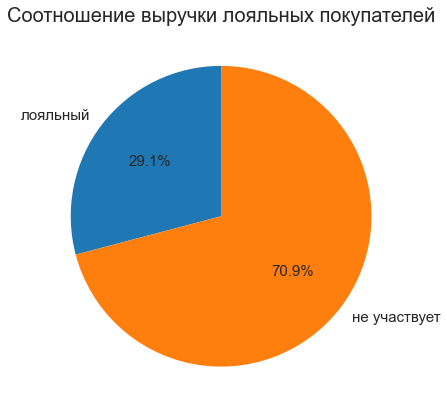

```python
fig2, ax2 = plt.subplots()
ax2.pie(customers2['revenue'], labels=customers2['loyalty_program'], autopct='%1.1f%%', startangle = 90, textprops={'fontsize':15})
ax2.axis('equal')
ax2.set_title('Соотношение выручки лояльных покупателей', fontsize=20)
fig2.set_figheight(7)
plt.show()
```

Около 30 % выручки принесли лояльные клиенты.

Посмотрим долю количества заказов лояльных клиентов.

```python
customers3 = data.query('shop_id == "Shop 0"').groupby('loyalty_program')['purchase_id'].nunique().reset_index()
customers3
```

|  | loyalty_program | purchase_id |
| --- | --- | --- |
| 0 | лояльный | 1053 |
| 1 | не участвует | 2102 |

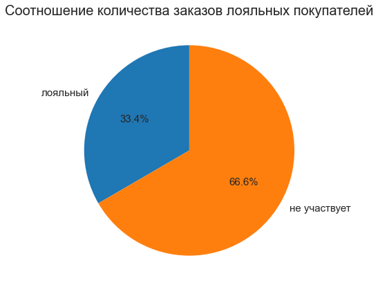

```python
fig3, ax3 = plt.subplots()
ax3.pie(customers3['purchase_id'], labels=customers3['loyalty_program'], autopct='%1.1f%%', startangle = 90, textprops={'fontsize':15})
ax3.axis('equal')
ax3.set_title('Соотношение количества заказов лояльных покупателей', fontsize=20)
fig3.set_figheight(7)
plt.show()
```

Около 33 % заказов было совершено лояльными клиентами.

### Динамика основных метрик в рамках программы лояльности.

Создадим таблицу для анализа метрик по датам.

```python
purchase_date = data.query('shop_id == "Shop 0"').groupby(['date', 'loyalty_program', 'month', 'week', 'weekday']).agg({'revenue':'sum', 'purchase_id':'nunique', 'customer_id':'nunique'}).reset_index()
purchase_date['month'] = purchase_date['month'].replace({1: 'январь', 2: 'февраль', 12: 'декабрь'})
purchase_date['date'] = pd.to_datetime(purchase_date['date'])
purchase_date['date'] = purchase_date['date'].dt.strftime('%Y-%m-%d')
purchase_date
```

|  | date | loyalty_program | month | week | weekday | revenue | purchase_id | customer_id |
| --- | --- | --- | --- | --- | --- | --- | --- | --- |
| 0 | 2016-12-01 | лояльный | декабрь | 48 | 3 | 11083.275 | 45 | 34 |
| 1 | 2016-12-01 | не участвует | декабрь | 48 | 3 | 23123.885 | 62 | 54 |
| 2 | 2016-12-02 | лояльный | декабрь | 48 | 4 | 14793.280 | 57 | 30 |
| 3 | 2016-12-02 | не участвует | декабрь | 48 | 4 | 22056.365 | 67 | 62 |
| 4 | 2016-12-03 | лояльный | декабрь | 48 | 5 | 5608.935 | 20 | 18 |
| ... | ... | ... | ... | ... | ... | ... | ... | ... |
| 131 | 2017-02-25 | не участвует | февраль | 8 | 5 | 13694.840 | 35 | 32 |
| 132 | 2017-02-27 | лояльный | февраль | 9 | 0 | 1664.765 | 8 | 7 |
| 133 | 2017-02-27 | не участвует | февраль | 9 | 0 | 7417.985 | 22 | 22 |
| 134 | 2017-02-28 | лояльный | февраль | 9 | 1 | 3611.625 | 15 | 15 |
| 135 | 2017-02-28 | не участвует | февраль | 9 | 1 | 12036.655 | 32 | 30 |

136 rows × 8 columns

```python
# создадим датафрейм со всеми датами за заданный период
calendar = pd.date_range(
start = purchase_date['date'].min(),
freq = 'D',
end = purchase_date['date'].max())
calendar = pd.DataFrame(calendar, columns = ['date'])
calendar['date'] = pd.to_datetime(calendar['date'])
calendar['date'] = calendar['date'].dt.strftime('%Y-%m-%d')
calendar.head()
```

|  | date |
| --- | --- |
| 0 | 2016-12-01 |
| 1 | 2016-12-02 |
| 2 | 2016-12-03 |
| 3 | 2016-12-04 |
| 4 | 2016-12-05 |

```python
# добавим недостающие даты в исходный датафрейм
purchase_date = purchase_date.merge(calendar, on = 'date', how='outer')
```

```python
# заполним пропуски нулями, для отображения выходных дней на графике
purchase_date['customer_id'] = purchase_date['customer_id'].fillna(0)
purchase_date = purchase_date.sort_values(by = 'date')
```

#### Анализ количества уникальных клиентов по дням, месяцам.

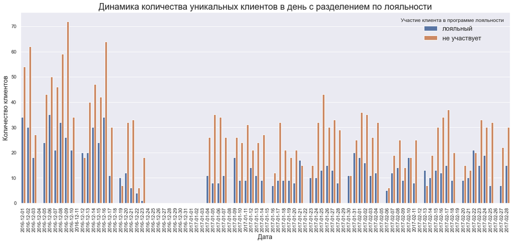

```python
sns.set(rc = {'figure.figsize':(20,8)})
sns.barplot(x = 'date',
            y = 'customer_id',
            hue = 'loyalty_program',
            data = purchase_date,
            ci = 0)

plt.title('Динамика количества уникальных клиентов в день с разделением по лояльности', fontsize=20)
plt.legend(title = 'Участие клиента в программе лояльности', fontsize=15)
plt.ylabel('Количество клиентов', fontsize=15)
plt.xlabel('Дата', fontsize=15)
plt.xticks(rotation=90)
plt.show()
```

В целом динамика графиков выглядит похожей: максимальные значения до середины декабря и в предпразднечные дни (что характерно, выходные дни на графике соответствуют католическим празникам). График вполне коррелирует с графиком истории запросов на строительные материалы за 2022-2023гг., на сайте сервиса Яндекс Подбор слов. Это подтверждает гипотезу о наличии сезонности и корректности данных. Далее общий спади отсутствие клиентов, что указывает на то, что скорее всего магазин в эти дни не работал. Начало активности клиентов наблюдается с 4 января.

Количество лояльных клиентов практически всегда ниже остальных. Посмотрим динамику по месяцам.

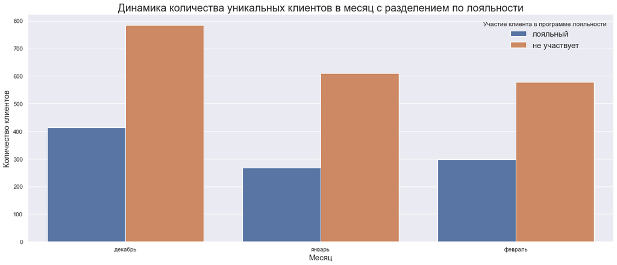

```python
sns.set(rc = {'figure.figsize':(20,8)})
sns.barplot(x = 'month',
            y = purchase_date['customer_id'],
            hue = 'loyalty_program',
            data = purchase_date,
            ci = 0,
           estimator=sum)

plt.title('Динамика количества уникальных клиентов в месяц с разделением по лояльности', fontsize=20)
plt.legend(title = 'Участие клиента в программе лояльности', fontsize=15)
plt.ylabel('Количество клиентов', fontsize=15)
plt.xlabel('Месяц', fontsize=15)
plt.show()
```

В декабре мы наблюдаем наибольшее количество клиентов из обеих групп. Возможно это связано с желанием закупится по ценам текущего года. Или с проведением праздничных акций. Можно отметить тот факт, что количество лояльных клиентов в феврале увеличилось в сравнении с январем, а количество остальных клиентов уменьшилось.

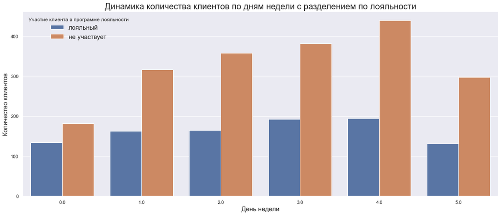

```python
sns.set(rc = {'figure.figsize':(20,8)})
sns.barplot(x = 'weekday',
            y = purchase_date['customer_id'],
            hue = 'loyalty_program',
            data = purchase_date,
            ci = 0,
           estimator=sum)

plt.title('Динамика количества клиентов по дням недели с разделением по лояльности', fontsize=20)
plt.legend(title = 'Участие клиента в программе лояльности', fontsize=15)
plt.ylabel('Количество клиентов', fontsize=15)
plt.xlabel('День недели', fontsize=15)
plt.show()
```

Количество лояльных клиентов по дням распространяется более плавно, чем количество остальных клиентов. Это говорит о том, что лояльные клиенты менее подвержены влиянию дня недели. Но тенденция динамики сохранена в обеих группах.

#### Анализ среднего чека и выручки.

Добавим столбец с средним чеком.

```python
purchase_date['average_check'] = round((purchase_date['revenue'] / purchase_date['purchase_id']), 2)
```

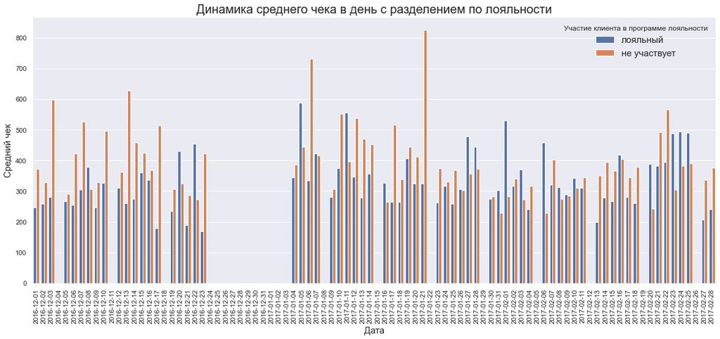

```python
sns.set(rc = {'figure.figsize':(20,8)})
sns.barplot(x = 'date',
            y = 'average_check',
            hue = 'loyalty_program',
            data = purchase_date,
            ci = 0)

plt.title('Динамика среднего чека в день с разделением по лояльности', fontsize=20)
plt.legend(title = 'Участие клиента в программе лояльности', fontsize=15)
plt.ylabel('Средний чек', fontsize=15)
plt.xlabel('Дата', fontsize=15)
plt.xticks(rotation=90)
plt.show()
```

Средний чек участников программы лояльности в основном ниже среднего чека остальных клиентов. Большой пик среднего чека среди лояльных клиентов наблюдается 5 января. Средний чек лояльных клиентов улучшился в 2017 году по сравнению с 2016 годом. Посмотрим на динамику среднего чека по месяцам.

```python
data['date_month'] = data['date'].astype('datetime64[M]').dt.strftime('%Y-%m')
check_month = data.query("shop_id == 'Shop 0'").groupby(['date_month', 'loyalty_program']).agg({'revenue':'sum', 'purchase_id':'nunique'}).reset_index()
check_month['average_check'] = round((check_month['revenue'] / check_month['purchase_id']), 2)
check_month
```

|  | date_month | loyalty_program | revenue | purchase_id | average_check |
| --- | --- | --- | --- | --- | --- |
| 0 | 2016-12 | лояльный | 137973.140 | 476 | 289.86 |
| 1 | 2016-12 | не участвует | 346946.355 | 866 | 400.63 |
| 2 | 2017-01 | лояльный | 93291.815 | 270 | 345.53 |
| 3 | 2017-01 | не участвует | 266914.460 | 634 | 421.00 |
| 4 | 2017-02 | лояльный | 107732.750 | 307 | 350.92 |
| 5 | 2017-02 | не участвует | 211696.505 | 602 | 351.66 |

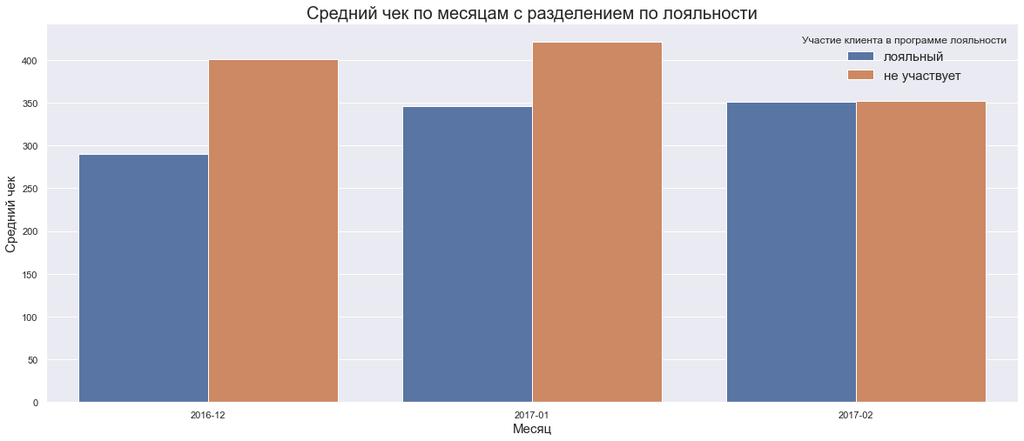

```python
sns.set(rc = {'figure.figsize':(20,8)})
sns.barplot(x = 'date_month',
            y = 'average_check',
            hue = 'loyalty_program',
            data = check_month,
            ci = 0
           )

plt.title('Средний чек по месяцам с разделением по лояльности', fontsize=20)
plt.legend(title = 'Участие клиента в программе лояльности', fontsize=15)
plt.ylabel('Средний чек', fontsize=15)
plt.xlabel('Месяц', fontsize=15)
plt.show()
```

Наблюдается тенденция к росту среднего чека лояльных клиентов и снижению среднего чека нелояльных клиентов. Так как заметного увеличения лояльных клиентов в феврале не наблюдалось, можно сделать вывод, что программа лояльности повлияла на то, чтобы лояльные клиенты больше тратились.

Посмотрим как менялась выручка по дням.

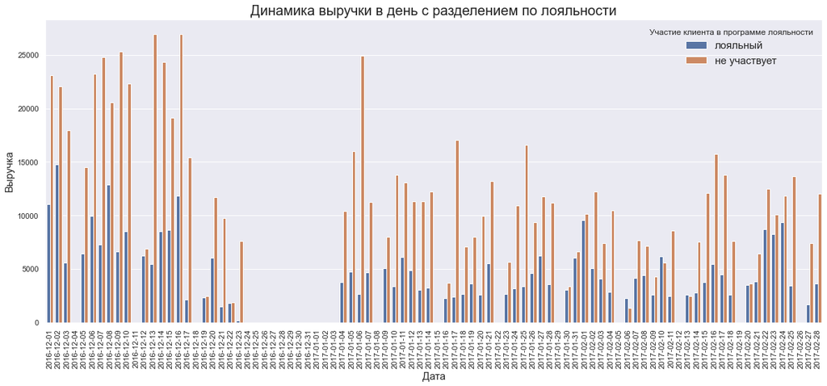

```python
sns.set(rc = {'figure.figsize':(20,8)})
sns.barplot(x = 'date',
            y = 'revenue',
            hue = 'loyalty_program',
            data = purchase_date,
            ci = 0)

plt.title('Динамика выручки в день с разделением по лояльности', fontsize=20)
plt.legend(title = 'Участие клиента в программе лояльности', fontsize=15)
plt.ylabel('Выручка', fontsize=15)
plt.xlabel('Дата', fontsize=15)
plt.xticks(rotation=90)
plt.show()
```

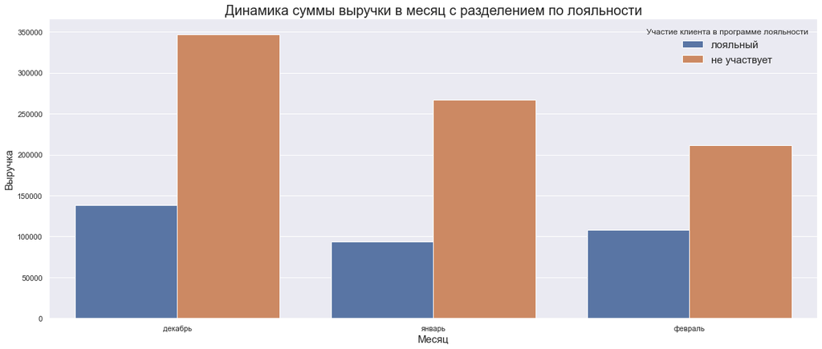

```python
sns.set(rc = {'figure.figsize':(20,8)})
sns.barplot(x = 'month',
            y = 'revenue',
            hue = 'loyalty_program',
            data = purchase_date,
            ci = 0,
            estimator=sum
           )

plt.title('Динамика суммы выручки в месяц с разделением по лояльности', fontsize=20)
plt.legend(title = 'Участие клиента в программе лояльности', fontsize=15)
plt.ylabel('Выручка', fontsize=15)
plt.xlabel('Месяц', fontsize=15)
plt.show()
```

Посмотрим как менялась средняя сумма заказов на одного клиента в каждой из групп.

```python
purchase_date['average_revenue'] = round((purchase_date['revenue'] / purchase_date['customer_id']), 2)
```

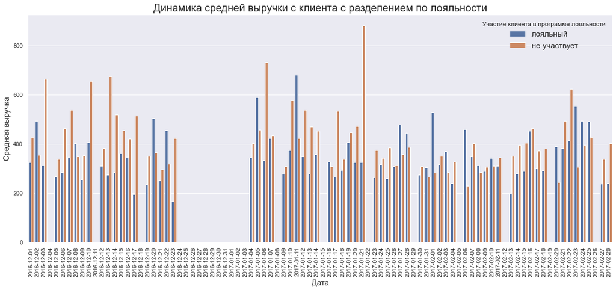

```python
sns.set(rc = {'figure.figsize':(20,8)})
sns.barplot(x = 'date',
            y = 'average_revenue',
            hue = 'loyalty_program',
            data = purchase_date,
            ci = 0)

plt.title('Динамика средней выручки с клиента с разделением по лояльности', fontsize=20)
plt.legend(title = 'Участие клиента в программе лояльности', fontsize=15)
plt.ylabel('Средняя выручка', fontsize=15)
plt.xlabel('Дата', fontsize=15)
plt.xticks(rotation=90)
plt.show()
```

```python
revenue_month = data.query("shop_id == 'Shop 0'").groupby(['date_month', 'loyalty_program']).agg({'revenue':'sum', 'customer_id':'nunique'}).reset_index()
revenue_month['average_revenue'] = round((revenue_month['revenue'] / revenue_month['customer_id']), 2)
revenue_month
```

|  | date_month | loyalty_program | revenue | customer_id | average_revenue |
| --- | --- | --- | --- | --- | --- |
| 0 | 2016-12 | лояльный | 137973.140 | 309 | 446.52 |
| 1 | 2016-12 | не участвует | 346946.355 | 622 | 557.79 |
| 2 | 2017-01 | лояльный | 93291.815 | 219 | 425.99 |
| 3 | 2017-01 | не участвует | 266914.460 | 498 | 535.97 |
| 4 | 2017-02 | лояльный | 107732.750 | 243 | 443.34 |
| 5 | 2017-02 | не участвует | 211696.505 | 484 | 437.39 |

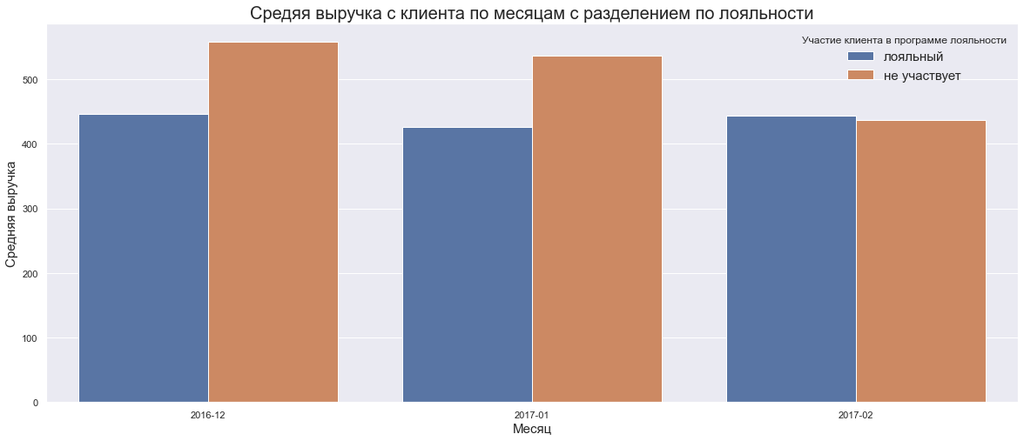

```python
sns.set(rc = {'figure.figsize':(20,8)})
sns.barplot(x = 'date_month',
            y = 'average_revenue',
            hue = 'loyalty_program',
            data = revenue_month,
            ci = 0
           )

plt.title('Средяя выручка с клиента по месяцам с разделением по лояльности', fontsize=20)
plt.legend(title = 'Участие клиента в программе лояльности', fontsize=15)
plt.ylabel('Средняя выручка', fontsize=15)
plt.xlabel('Месяц', fontsize=15)
plt.show()
```

#### Анализ количества покупок.

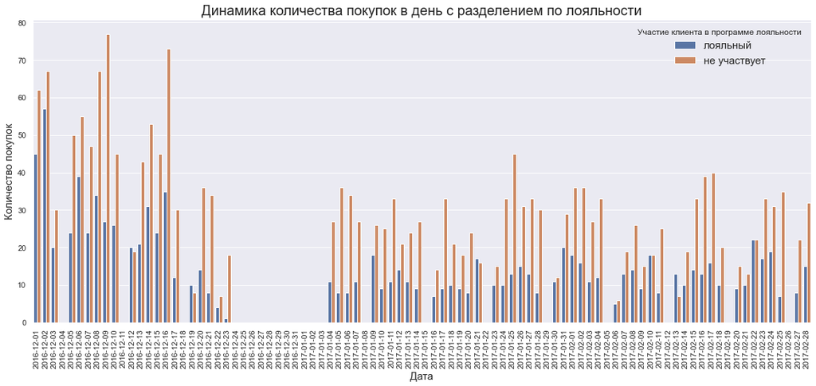

```python
sns.set(rc = {'figure.figsize':(20,8)})
sns.barplot(x = 'date',
            y = 'purchase_id',
            hue = 'loyalty_program',
            data = purchase_date,
            ci = 0)

plt.title('Динамика количества покупок в день с разделением по лояльности', fontsize=20)
plt.legend(title = 'Участие клиента в программе лояльности', fontsize=15)
plt.ylabel('Количество покупок', fontsize=15)
plt.xlabel('Дата', fontsize=15)
plt.xticks(rotation=90)
plt.show()
```

Покупок меньше у лояльных клиентов на протяжении практически всего периода. Возможно это объяснимо большим количеством оптовых покупателей среди нелояльных клиентов.

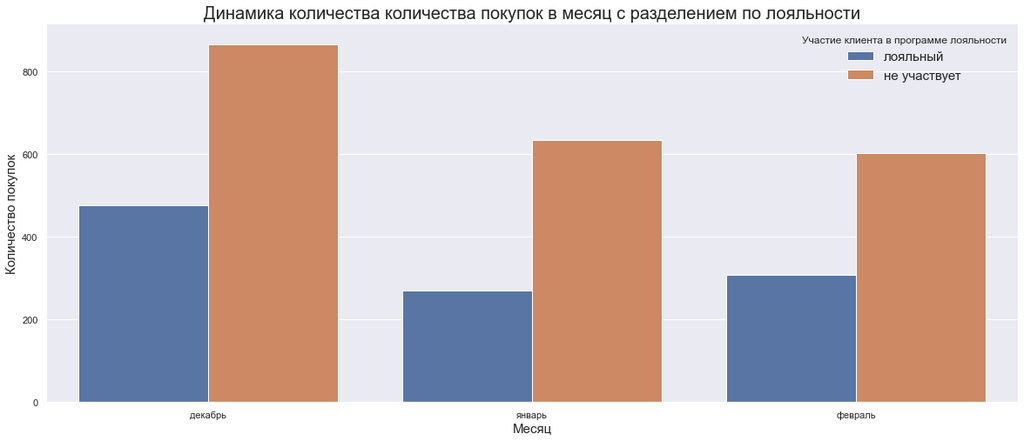

```python
sns.set(rc = {'figure.figsize':(20,8)})
sns.barplot(x = 'month',
            y = 'purchase_id',
            hue = 'loyalty_program',
            data = purchase_date,
            ci = 0,
           estimator=sum)

plt.title('Динамика количества количества покупок в месяц с разделением по лояльности', fontsize=20)
plt.legend(title = 'Участие клиента в программе лояльности', fontsize=15)
plt.ylabel('Количество покупок', fontsize=15)
plt.xlabel('Месяц', fontsize=15)
plt.show()
```

Лояльные клиенты стали покупать чаще в феврале, а нелояльные реже, в этом прослеживается позитивное влияние программы лояльности.

Посмотрим динамику среднего количества покупок на одного человека по дням , месяцам.

```python
purchase_date['average_purchase'] = round((purchase_date['purchase_id'] / purchase_date['customer_id']), 2)
```

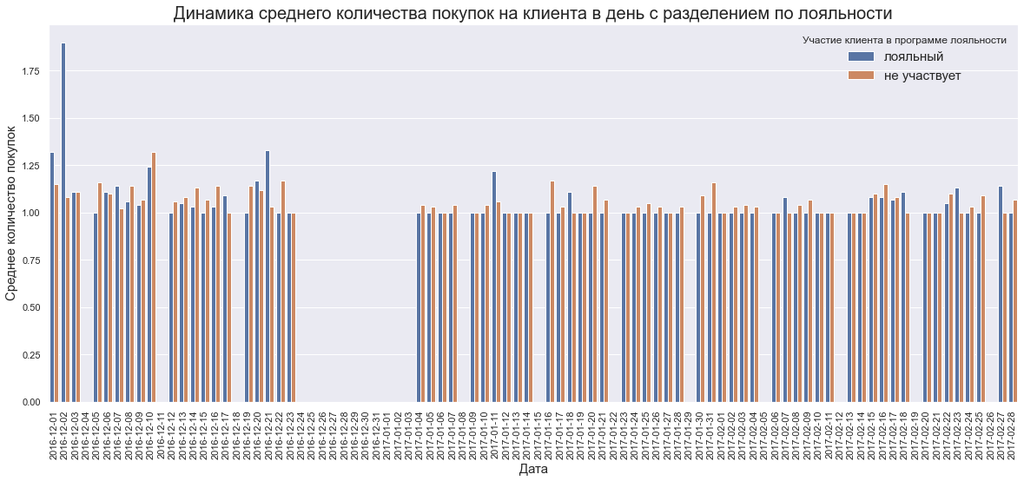

```python
sns.set(rc = {'figure.figsize':(20,8)})
sns.barplot(x = 'date',
            y = 'average_purchase',
            hue = 'loyalty_program',
            data = purchase_date,
            ci = 0)

plt.title('Динамика среднего количества покупок на клиента в день с разделением по лояльности', fontsize=20)
plt.legend(title = 'Участие клиента в программе лояльности', fontsize=15)
plt.ylabel('Среднее количество покупок', fontsize=15)
plt.xlabel('Дата', fontsize=15)
plt.xticks(rotation=90)
plt.show()
```

Пик заказов лояльных клиентов приходится на 2 декабря. Необходимо посмотреть на динамику среднего количества покупок на клиента по месяцам.

```python
purchase_month = data.query("shop_id == 'Shop 0'").groupby(['date_month', 'loyalty_program']).agg({'customer_id':'nunique', 'purchase_id':'nunique'}).reset_index()
purchase_month['average_purchase'] = round((purchase_month['purchase_id'] / purchase_month['customer_id']), 2)
purchase_month
```

|  | date_month | loyalty_program | customer_id | purchase_id | average_purchase |
| --- | --- | --- | --- | --- | --- |
| 0 | 2016-12 | лояльный | 309 | 476 | 1.54 |
| 1 | 2016-12 | не участвует | 622 | 866 | 1.39 |
| 2 | 2017-01 | лояльный | 219 | 270 | 1.23 |
| 3 | 2017-01 | не участвует | 498 | 634 | 1.27 |
| 4 | 2017-02 | лояльный | 243 | 307 | 1.26 |
| 5 | 2017-02 | не участвует | 484 | 602 | 1.24 |

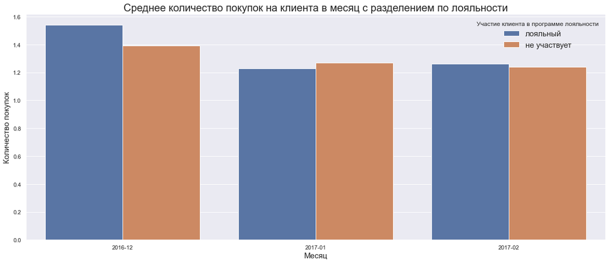

```python
sns.set(rc = {'figure.figsize':(20,8)})
sns.barplot(x = 'date_month',
            y = 'average_purchase',
            hue = 'loyalty_program',
            data = purchase_month,
            ci = 0
           )

plt.title('Среднее количество покупок на клиента в месяц с разделением по лояльности', fontsize=20)
plt.legend(title = 'Участие клиента в программе лояльности', fontsize=15)
plt.ylabel('Количество покупок', fontsize=15)
plt.xlabel('Месяц', fontsize=15)
plt.show()
```

### Вывод

Мы рассмотрели основные метрики в динамике, поделив клиентов на группы в рамках программы лояльности среди покупателей магазина Shop 0 и выявили :

- доля лояльных клиентов составляет около 30 % от общего количества клиентов
- около 30 % выручки принесли лояльные клиенты
- около 33 % заказов было совершено лояльными клиентами

Период, за каторый предоставлены данные захватывает ногодние и рождественские праздники. В связи с этим наблюдается большая активность в декабре. В связи с этим динамика неоднородна. Также прослеживается сезонность строительных товаров.

Рассмотрев динамику основных метрик по дням, месяцам, мы можем сделать выводы:

1. Количество лояльных клиентов практически каждый рабочий день было меньше количества остальных клиентов. Но отметим небольшое увеличение количества лояльных покупателей в феврале.
2. Лояльные клиенты менее подвержены влиянию дня недели. Но тенденции к минимальным значениям по понедельникам и субботам и стремление к максимуму в пятницу сохранены.
3. Средний чек участников программы лояльности в основном ниже среднего чека остальных клиентов. Средний чек лояльных клиентов улучшился в 2017 году по сравнению с 2016 годом. Наблюдается тенденция к росту среднего чека лояльных клиентов и снижению среднего чека нелояльных клиентов по месяцам. Так как заметного увеличения лояльных клиентов в феврале не наблюдалось, можно сделать вывод, что **программа лояльности повлияла на то, чтобы лояльные клиенты больше тратились**.
4. Общая выручка по группам в день на протяжении практически всего периода у лояльных клиентов ниже чем у остальных. Но это логично, так как в целом их меньше. Мы наблюдаем хоть и небольшой, но *рост выручки лояльных покупателей в феврале*.

1. Покупок меньше у лояльных клиентов на протяжении практически всего периода. Кроме того, что лояльных покупателей меньше, также это возможно объяснить наличием оптовых покупателей среди нелояльных клиентов.

Однако, *лояльные клиенты стали покупать чаще в феврале*, а нелояльные реже, в этом прослеживается **позитивное влияние программы лояльности**.

## Проверка статистических гипотез.

### Проверка гипотезы о равенстве средних чеков.

Нулевая гипотеза: средний чек участников программы и остальных покупателей равен.

Альтернативная гипотеза: средний чек участников программы и остальных покупателей - отличается .

```python
purchases_1 = data.query('shop_id == "Shop 0"').pivot_table(index=('purchase_id', 'loyalty_program'), values =  'revenue', aggfunc='sum').reset_index()
purchases_1
```

|  | purchase_id | loyalty_program | revenue |
| --- | --- | --- | --- |
| 0 | 536365 | лояльный | 186.515 |
| 1 | 536366 | лояльный | 19.750 |
| 2 | 536367 | не участвует | 285.395 |
| 3 | 536368 | не участвует | 96.090 |
| 4 | 536369 | не участвует | 13.200 |
| ... | ... | ... | ... |
| 3150 | 545214 | лояльный | 218.710 |
| 3151 | 545215 | не участвует | 605.455 |
| 3152 | 545216 | не участвует | 523.540 |
| 3153 | 545217 | не участвует | 479.605 |
| 3154 | 545218 | лояльный | 720.415 |

3155 rows × 3 columns

```python
array_1 = purchases_1[purchases_1['loyalty_program'] == 'лояльный']['revenue']
array_1.mean()
```

```
321.93514245014234
```

```python
array_0 = purchases_1[purchases_1['loyalty_program'] == 'не участвует']['revenue']
array_0.mean()
```

```
392.7484871550911
```

```python
array_1.shape
```

```
(1053,)
```

```python
array_0.shape
```

```
(2102,)
```

Средние выборок по расчетам не равны. Мы будем использовать метод ttest_ind. Также учтем параметр equal_var, так как размеры выборок значительно различаются.

```python
alpha = .05

results = st.ttest_ind(
array_1,
array_0,
equal_var=False
)

print('p-значение:', results.pvalue)

if results.pvalue < alpha:
    print("Отвергаем нулевую гипотезу")
else:
    print("Не получилось отвергнуть нулевую гипотезу")
```

```
p-значение: 1.2205467178042973e-06
Отвергаем нулевую гипотезу
```

p-значение значительно меньше alpha, это значит, что между выборками имеется статистическая значимость и средние выборок отличаются. Мы отвергаем нулевую гипотезу.

### Проверка гипотезы о том, что среднее количество заказов на клиента участников программы и остальных покупателей равны.

Нулевая гипотеза: среднее количество заказов на клиента участников программы и остальных покупателей равно.

Альтернативная гипотеза: среднее количество заказов на клиента участников программы и остальных покупателей отличается.

```python
purchases_2 = data.query('shop_id == "Shop 0"').pivot_table(index=('customer_id', 'loyalty_program'), values =  'purchase_id', aggfunc='nunique').reset_index()
purchases_2
```

|  | customer_id | loyalty_program | purchase_id |
| --- | --- | --- | --- |
| 0 | 18426.0 | не участвует | 3 |
| 1 | 18427.0 | не участвует | 35 |
| 2 | 18499.0 | не участвует | 1 |
| 3 | 18502.0 | не участвует | 2 |
| 4 | 18505.0 | не участвует | 3 |
| ... | ... | ... | ... |
| 1782 | 545078 | не участвует | 1 |
| 1783 | 545176 | не участвует | 1 |
| 1784 | 545215 | не участвует | 1 |
| 1785 | 545216 | не участвует | 1 |
| 1786 | 545217 | не участвует | 1 |

1787 rows × 3 columns

```python
array2_1 = purchases_2[purchases_2['loyalty_program'] == 'лояльный']['purchase_id']
array2_1.mean()
```

```
1.9536178107606679
```

```python
array2_0 = purchases_2[purchases_2['loyalty_program'] == 'не участвует']['purchase_id']
array2_0.mean()
```

```
1.6842948717948718
```

```python
array2_1.shape
```

```
(539,)
```

```python
array2_0.shape
```

```
(1248,)
```

```python
alpha = .05

results = st.ttest_ind(
array2_1,
array2_0,
equal_var=False
)

print('p-значение:', results.pvalue)

if results.pvalue < alpha:
    print("Отвергаем нулевую гипотезу")
else:
    print("Не получилось отвергнуть нулевую гипотезу")
```

```
p-значение: 0.012524850708204307
Отвергаем нулевую гипотезу
```

p-значение меньше alpha, это значит, что между выборками имеется статистическая значимость и средние выборок отличаются. Мы отвергаем нулевую гипотезу.

## Общий вывод.

Прежде чем перейти к анализу, мы провели обзор и предобработку данных:

- мы переименовали столбцы в соответствие с "хорошим" стилем.
- проработали ситуацию с пропусками в столбце customer_id- мы заменили их насоответствующие именования чеков.
- изменили тип данных некоторых столбцов для удобства работы с данными
- проверка на явные дубликаты показала их наличие в количестве 1033 строк. Мы решили их удалить, так как их количество невелико и их удаление не повлияет на качество исследования.

Для того, чтобы провести дальнейшее исследование, необходимо было объединить датафреймы с покупками и с ценами на товары. Предварительно мы выявили некоторое количество непродуктовых кодов, и удалили строки с ними. Мы решили сагрегировать цены на товары в таблице products по медианной цене.

В итоге мы получили 103745 строк и 8 столбцов в новом объединенном датафрейме.

Проведя проверку гипотез мы сделали вывод, что различия в среднем чеке и количестве заказов на клиента получили статистическую значимость, это говорит нам о том, что есть основания предполагать, что они отличны у групп клиентов, поделенных в зависимости от участия в программе лояльности.

Наши рекомендации:

- что программу лояльности нужно продолжить, но модернизировать для увеличения привлечения в нее клиентов
- изучить оптовые заказы, распространить программу лояльности на клиентов, осуществляющих их
- было бы неплохо рассмотреть данные с учетом количества возвратов, например, так как они могли повлиять на метрики.